# Assignment week 8

Carla Ebner

2025-04-16

```r
suppressPackageStartupMessages({
  library(epiwraps)
  library(motifmatchr)
  library(MotifDb)
  library(universalmotif)
  library(ggplot2)
  library(SummarizedExperiment) # data structure
  library(sechm) # for plotting heatmaps from a SummrizedExperiment
  library(BiocParallel) # for multithreading
  library(chromVAR) # for motif accessibility estimation
  library(limma) # for statistical analysis
  library(TFBSTools)
  library(AnnotationHub)
})
```

```
## See system.file("LICENSE", package="MotifDb") for use restrictions.
```

```r
register(SnowParam(2))
```

# Prepare all the data for the analysis

### First we download the ATAC-seq peak counts in the hippocampus upon stress

```r
options(timeout=6000)
download.file("https://ethz-ins.org/content/mouse_mm38_hippocampus.peakCounts.SE.rds", "stress.SE.rds", mode="wb")
se <- readRDS("stress.SE.rds")
head(se)
```

```
## class: RangedSummarizedExperiment
## dim: 6 12
## metadata(0):
## assays(1): counts
## rownames: NULL
## rowData names(0):
## colnames(12): Control_female_GSM6041841.bam
##   Control_female_GSM6041842.bam ... FSS_male_GSM6041857.bam
##   FSS_male_GSM6041858.bam
## colData names(1): depth
```

### Then we download the mouse genome

```r
ah <- AnnotationHub()
genome <- ah[["AH68356"]]
```

```
## loading from cache
```

```
## require("rtracklayer")
```

```r
genes <- import(genome)
```

### Now we get the database of motifs

```r
motifs <- MotifDb::query(MotifDb, c("HOCOMOCOv10", "Mmusculus"))
motifs <- do.call(TFBSTools::PWMatrixList, setNames(
           universalmotif::convert_motifs(motifs, class="TFBSTools-PWMatrix"),
           mcols(motifs)$geneSymbol))
motifs <- motifs[unique(names(motifs))]
```

### We check to see which samples are control/FSS and which are female/male

```r
head(assay(se))
```

```
## 6 x 12 Matrix of class "dgeMatrix"
##      Control_female_GSM6041841.bam Control_female_GSM6041842.bam
## [1,]                            32                             2
## [2,]                            17                            27
## [3,]                            36                            35
## [4,]                            36                            58
## [5,]                            57                            44
## [6,]                            34                            35
##      Control_female_GSM6041843.bam Control_male_GSM6041844.bam
## [1,]                             0                          18
## [2,]                             0                           7
## [3,]                            47                          14
## [4,]                           109                           1
## [5,]                             1                           6
## [6,]                             0                          18
```

[output cut: 28 more lines]

### Now we assign the conditions (CTRL/FSS) and sex (F/M) and set the row names

```r
colData(se)$condition <- c("CTRL","CTRL","CTRL","CTRL","CTRL","CTRL","FSS","FSS","FSS","FSS","FSS","FSS")
colData(se)$sex <- c("F","F","F","M","M","M","F","F","F","M","M","M")
row.names(se) <- as.character(granges(se))
```

### We add the GC-bias to the se data and see in the histogram that the distribution seems normal

```r
se <- chromVAR::addGCBias(se, genome=genes)
rowData(se)
```

```
## DataFrame with 20660 rows and 1 column
##                          bias
##                     <numeric>
## 1:3012609-3012858       0.348
## 1:3094941-3095190       0.424
## 1:3113634-3113883       0.448
## 1:3119522-3119771       0.448
## 1:3119880-3120129       0.432
## ...                       ...
## Y:90744317-90744566     0.636
## Y:90744689-90744938     0.544
## Y:90761326-90761575     0.640
## Y:90804984-90805233     0.472
## Y:90808700-90808949     0.416
```

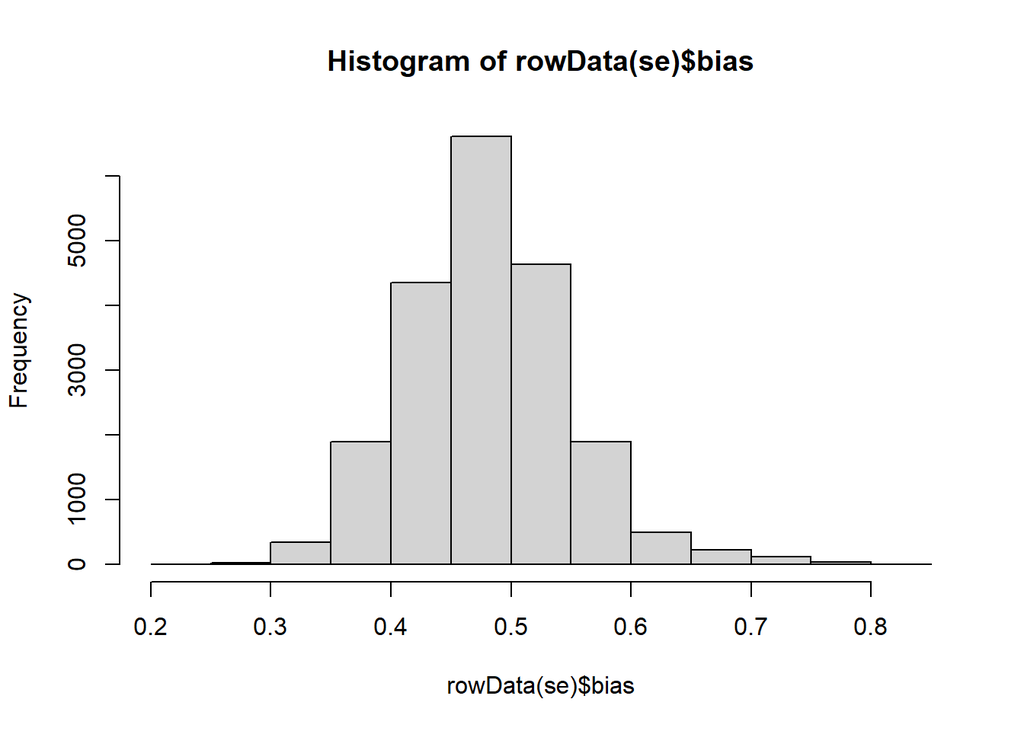

```r
hist(rowData(se)$bias)
```

### We search the motifs in our se data (peaks)

```r
moi <- motifmatchr::matchMotifs(motifs, subject=se, genome=genes)
head(assay(moi))
```

```
## 6 x 395 sparse Matrix of class "lgCMatrix"
```

```
##   [[ suppressing 395 column names 'AHR', 'AIRE', 'ALX1' ... ]]
```

[output not shown]

[output cut: 36 more lines]

[output not shown]

### We ensure the reproducibility

```r
set.seed(1234)
bg <- chromVAR::getBackgroundPeaks(se, niterations=500)
dev <- chromVAR::computeDeviations(object = se, annotations=moi,
                                   background_peaks=bg)
```

# Differential analysis

### We specify the baseline conditions (here: “CTRL” and “F”) for “condition” and “sex”

```r
dev$condition <- factor(dev$condition)
dev$condition <- relevel(dev$condition, "CTRL")

dev$sex <- factor(dev$sex)
dev$sex <- relevel(dev$sex, "F")
```

### Then we create two model matrices, fit the model and choose the coefficient from the model matrix that we want to test (FSS and M)

```r
mm_condition <- model.matrix(~condition, data=as.data.frame(colData(dev)))
mm_sex <- model.matrix(~sex, data=as.data.frame(colData(dev)))
```

```r
fit_condition <- limma::eBayes(limma::lmFit(object = assays(dev)$z, design = mm_condition))
fit_sex <- limma::eBayes(limma::lmFit(object = assays(dev)$z, design = mm_sex))
```

```r
res_condition <- as.data.frame(limma::topTable(fit_condition, coef="conditionFSS", number = Inf))
head(res_condition)
```

```
##           logFC     AveExpr         t      P.Value   adj.P.Val          B
## ANDR   8.076175  0.80086485  7.290848 3.709531e-06 0.001465265  4.4968829
## GCR    5.446964  0.77346629  5.424005 8.612719e-05 0.017010120  1.7003185
## PRGR   3.812420  0.07852143  3.944901 1.436546e-03 0.189145172 -0.8930885
## MSX2   1.925670  0.31524267  2.997381 9.500943e-03 0.938218150 -2.6387798
## MEF2A -2.517883  0.07800126 -2.333139 3.488337e-02 0.997094700 -3.8151187
## HIF1A -1.440568 -0.18795656 -2.280298 3.857490e-02 0.997094700 -3.9042763
```

```r
res_sex <- as.data.frame(limma::topTable(fit_sex, coef="sexM", number = Inf))
head(res_sex)
```

```
##           logFC    AveExpr          t      P.Value    adj.P.Val         B
## TYY1  -9.339389 -0.3391794 -10.127999 6.414073e-08 2.533559e-05 8.0811490
## TEAD1 -7.607290 -0.1710944  -8.211382 8.552918e-07 1.689201e-04 5.8958416
## RUNX3 -3.924641 -0.2081702  -7.338083 3.203539e-06 4.217992e-04 4.7295734
## MYB   -3.993046 -0.5614471  -5.808044 4.127760e-05 4.076163e-03 2.3972682
## PTF1A -3.021049 -0.3045415  -4.807187 2.610115e-04 2.061991e-02 0.6724578
## ZN143 -3.863902  0.2808465  -4.687587 3.281393e-04 2.160250e-02 0.4569511
```

# Results

## Top most significant motifs

### We search for the most significant motifs, which we use for the heatmap later. We see some significant differences in expression of the motifs in the CTRL vs. FSS groups and in the F vs. M groups

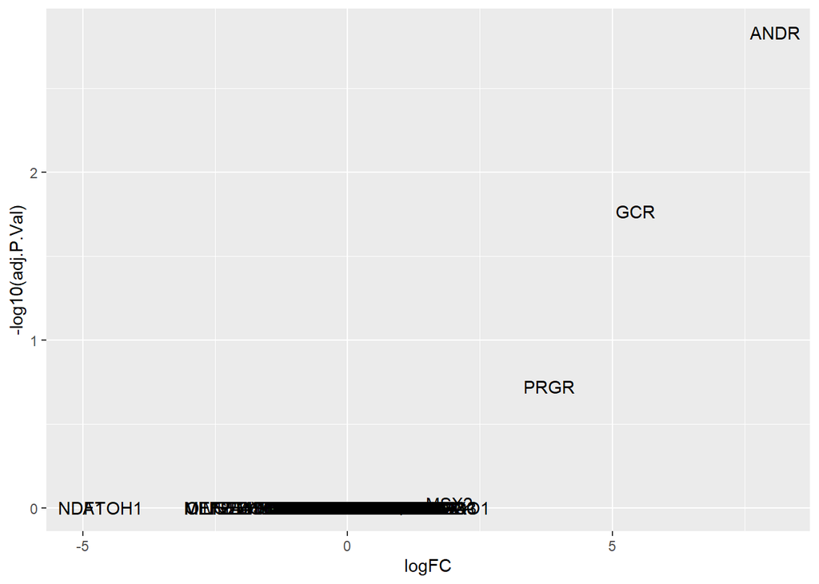

```r
res_condition$TF <- row.names(res_condition)
res_sex$TF <- row.names(res_sex)

ggplot(res_condition, aes(logFC, -log10(adj.P.Val), label=TF)) + geom_text()
```

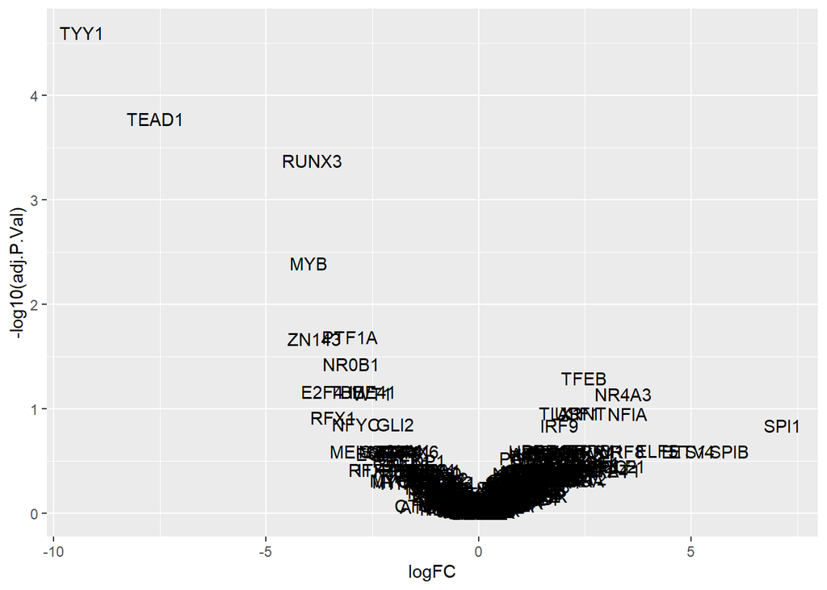

```r
ggplot(res_sex, aes(logFC, -log10(adj.P.Val), label=TF)) + geom_text()
```

## Heatmap

### We create a heatmap with the most significant motifs, which we ensured above with ordering by significance

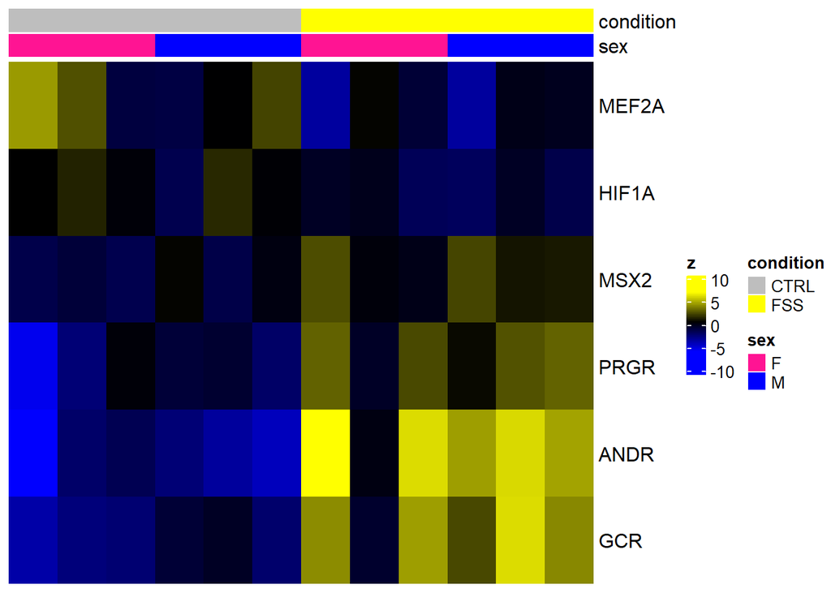

```r
metadata(dev)$anno_colors <- list(condition = c(CTRL = "grey", FSS = "yellow"), sex = c(F = "deeppink", M = "blue"))


sechm::sechm(dev, features = head(row.names(res_condition)), assayName="z", top_annotation = c("condition", "sex"))
```

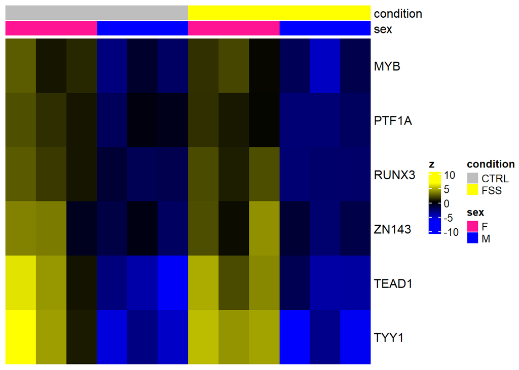

```r
sechm::sechm(dev, features = head(row.names(res_sex)), assayName="z", top_annotation = c("condition", "sex"))
```

## Interpreting the results

### F vs. M:

We can see a difference between the female and male samples in all motifs (MYB, PTF1A, RUNX3, ZN143, TEAD1 and TYY1), whereby the accessibility of these motifs is higher in females than in males.